# Risk Factor Analysis

## Outcome Variable

**Outcome Variable:** stunted

## Predictor Variables

**Intervention Variable:** birthlen

**Adjustment Set:**

unadjusted

## Stratifying Variables

The analysis was stratified on these variable(s):

- agecat
- studyid

The following strata were considered:

- agecat: 12 months, studyid: ki0047075b-MAL-ED
- agecat: 12 months, studyid: ki1000108-CMC-V-BCS-2002
- agecat: 12 months, studyid: ki1000108-IRC
- agecat: 12 months, studyid: ki1017093b-PROVIDE
- agecat: 12 months, studyid: ki1017093c-NIH-Crypto
- agecat: 12 months, studyid: ki1101329-Keneba
- agecat: 12 months, studyid: ki1126311-ZVITAMBO
- agecat: 12 months, studyid: ki1135781-COHORTS
- agecat: 18 months, studyid: ki0047075b-MAL-ED
- agecat: 18 months, studyid: ki1000108-CMC-V-BCS-2002
- agecat: 18 months, studyid: ki1000108-IRC
- agecat: 18 months, studyid: ki1017093b-PROVIDE
- agecat: 18 months, studyid: ki1017093c-NIH-Crypto
- agecat: 18 months, studyid: ki1101329-Keneba
- agecat: 18 months, studyid: ki1126311-ZVITAMBO
- agecat: 18 months, studyid: ki1135781-COHORTS
- agecat: 24 months, studyid: ki0047075b-MAL-ED
- agecat: 24 months, studyid: ki1000108-CMC-V-BCS-2002
- agecat: 24 months, studyid: ki1000108-IRC
- agecat: 24 months, studyid: ki1017093b-PROVIDE
- agecat: 24 months, studyid: ki1017093c-NIH-Crypto
- agecat: 24 months, studyid: ki1101329-Keneba
- agecat: 24 months, studyid: ki1126311-ZVITAMBO
- agecat: 24 months, studyid: ki1135781-COHORTS
- agecat: 3 months, studyid: ki0047075b-MAL-ED
- agecat: 3 months, studyid: ki1000108-CMC-V-BCS-2002
- agecat: 3 months, studyid: ki1000108-IRC
- agecat: 3 months, studyid: ki1017093b-PROVIDE
- agecat: 3 months, studyid: ki1017093c-NIH-Crypto
- agecat: 3 months, studyid: ki1101329-Keneba
- agecat: 3 months, studyid: ki1126311-ZVITAMBO
- agecat: 3 months, studyid: ki1135781-COHORTS
- agecat: 6 months, studyid: ki0047075b-MAL-ED
- agecat: 6 months, studyid: ki1000108-CMC-V-BCS-2002
- agecat: 6 months, studyid: ki1000108-IRC
- agecat: 6 months, studyid: ki1017093b-PROVIDE
- agecat: 6 months, studyid: ki1017093c-NIH-Crypto
- agecat: 6 months, studyid: ki1101329-Keneba
- agecat: 6 months, studyid: ki1126311-ZVITAMBO
- agecat: 6 months, studyid: ki1135781-COHORTS
- agecat: 9 months, studyid: ki0047075b-MAL-ED
- agecat: 9 months, studyid: ki1000108-CMC-V-BCS-2002
- agecat: 9 months, studyid: ki1000108-IRC
- agecat: 9 months, studyid: ki1017093b-PROVIDE
- agecat: 9 months, studyid: ki1017093c-NIH-Crypto
- agecat: 9 months, studyid: ki1101329-Keneba
- agecat: 9 months, studyid: ki1126311-ZVITAMBO
- agecat: 9 months, studyid: ki1135781-COHORTS
- agecat: Birth, studyid: ki0047075b-MAL-ED
- agecat: Birth, studyid: ki1000108-CMC-V-BCS-2002
- agecat: Birth, studyid: ki1000108-IRC
- agecat: Birth, studyid: ki1017093c-NIH-Crypto
- agecat: Birth, studyid: ki1101329-Keneba
- agecat: Birth, studyid: ki1126311-ZVITAMBO
- agecat: Birth, studyid: ki1135781-COHORTS

### Dropped Strata

Some strata were dropped due to rare outcomes:

- agecat: 12 months, studyid: ki0047075b-MAL-ED
- agecat: 12 months, studyid: ki1000108-CMC-V-BCS-2002
- agecat: 12 months, studyid: ki1017093b-PROVIDE
- agecat: 12 months, studyid: ki1017093c-NIH-Crypto
- agecat: 18 months, studyid: ki0047075b-MAL-ED
- agecat: 18 months, studyid: ki1000108-CMC-V-BCS-2002
- agecat: 18 months, studyid: ki1017093b-PROVIDE
- agecat: 18 months, studyid: ki1017093c-NIH-Crypto
- agecat: 24 months, studyid: ki0047075b-MAL-ED
- agecat: 24 months, studyid: ki1000108-CMC-V-BCS-2002
- agecat: 24 months, studyid: ki1017093b-PROVIDE
- agecat: 24 months, studyid: ki1017093c-NIH-Crypto
- agecat: 24 months, studyid: ki1126311-ZVITAMBO
- agecat: 3 months, studyid: ki0047075b-MAL-ED
- agecat: 3 months, studyid: ki1000108-CMC-V-BCS-2002
- agecat: 3 months, studyid: ki1017093b-PROVIDE
- agecat: 3 months, studyid: ki1017093c-NIH-Crypto
- agecat: 6 months, studyid: ki0047075b-MAL-ED
- agecat: 6 months, studyid: ki1000108-CMC-V-BCS-2002
- agecat: 6 months, studyid: ki1017093b-PROVIDE
- agecat: 6 months, studyid: ki1017093c-NIH-Crypto
- agecat: 9 months, studyid: ki0047075b-MAL-ED
- agecat: 9 months, studyid: ki1000108-CMC-V-BCS-2002
- agecat: 9 months, studyid: ki1017093b-PROVIDE
- agecat: 9 months, studyid: ki1017093c-NIH-Crypto
- agecat: Birth, studyid: ki0047075b-MAL-ED
- agecat: Birth, studyid: ki1000108-CMC-V-BCS-2002
- agecat: Birth, studyid: ki1000108-IRC
- agecat: Birth, studyid: ki1017093c-NIH-Crypto
- agecat: Birth, studyid: ki1101329-Keneba
- agecat: Birth, studyid: ki1126311-ZVITAMBO
- agecat: Birth, studyid: ki1135781-COHORTS

## Methods Detail

We’re interested in the causal parameters $E[Y_a]$ for all values of $a \in \mathcal{A}$. These parameters represent the mean outcome if, possibly contrary to fact, we intervened to set all units to have $A=a$. Under the randomization and positivity assumptions, these are identified by the statistical parameters $\psi_a=E_W[E_{Y|A,W}(Y|A=a,W)]$. In addition, we’re interested in the mean of $Y$, $E[Y]$ under no intervention (the observed mean). We will estimate these parameters by using SuperLearner to fit the relevant likelihood factors – $E_{Y|A,W}(Y|A=a,W)$ and $p(A=a|W)$, and then updating our likelihood fit using a joint TMLE.

For unadjusted analyses ($W=\{\}$), initial likelihoods were estimated using Lrnr_glm to estimate the simple $E(Y|A)$ and Lrnr_mean to estimate $p(A)$. For adjusted analyses, a small library containing Lrnr_glmnet, Lrnr_xgboost, and Lrnr_mean was used.

Having estimated these parameters, we will then use the delta method to estimate relative risks and attributable risks relative to a prespecified baseline level of $A$.

# Results Detail

## Results Plots

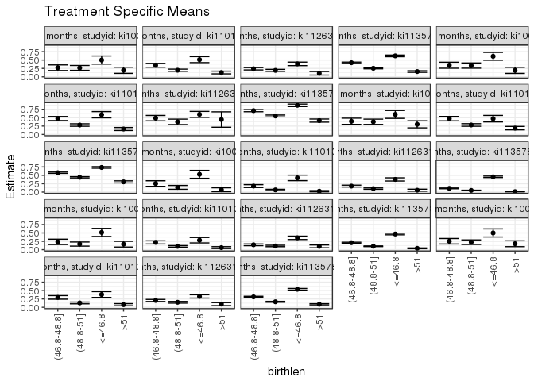

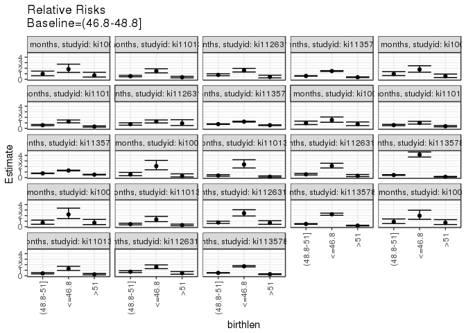

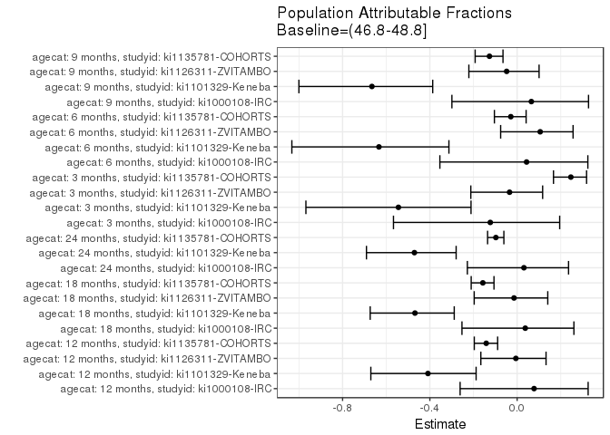

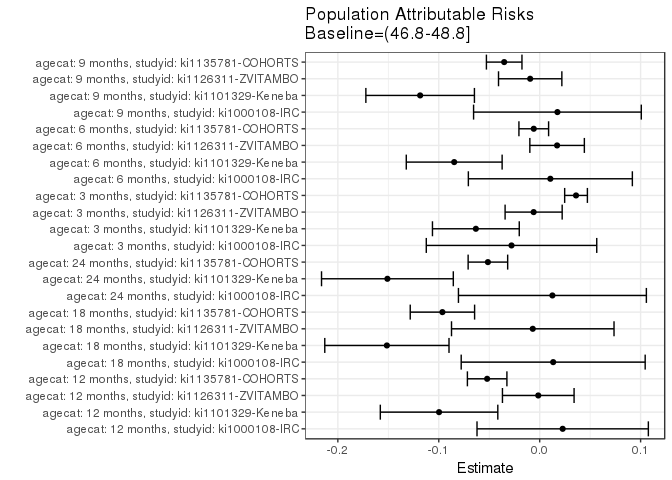

## Data Summary

| agecat | studyid | A | n | nA | nAY0 | nAY1 |
| --- | --- | --- | --- | --- | --- | --- |
| 12 months | ki0047075b-MAL-ED | (46.8-48.8] | 46 | 19 | 14 | 5 |
| 12 months | ki0047075b-MAL-ED | (48.8-51] | 46 | 11 | 11 | 0 |
| 12 months | ki0047075b-MAL-ED | <=46.8 | 46 | 16 | 8 | 8 |
| 12 months | ki0047075b-MAL-ED | >51 | 46 | 0 | 0 | 0 |
| 12 months | ki1000108-CMC-V-BCS-2002 | (46.8-48.8] | 102 | 33 | 21 | 12 |
| 12 months | ki1000108-CMC-V-BCS-2002 | (48.8-51] | 102 | 34 | 23 | 11 |
| 12 months | ki1000108-CMC-V-BCS-2002 | <=46.8 | 102 | 33 | 14 | 19 |
| 12 months | ki1000108-CMC-V-BCS-2002 | >51 | 102 | 2 | 1 | 1 |
| 12 months | ki1000108-IRC | (46.8-48.8] | 388 | 107 | 78 | 29 |
| 12 months | ki1000108-IRC | (48.8-51] | 388 | 143 | 105 | 38 |
| 12 months | ki1000108-IRC | <=46.8 | 388 | 66 | 33 | 33 |
| 12 months | ki1000108-IRC | >51 | 388 | 72 | 58 | 14 |
| 12 months | ki1017093b-PROVIDE | (46.8-48.8] | 153 | 59 | 36 | 23 |
| 12 months | ki1017093b-PROVIDE | (48.8-51] | 153 | 64 | 55 | 9 |
| 12 months | ki1017093b-PROVIDE | <=46.8 | 153 | 18 | 6 | 12 |
| 12 months | ki1017093b-PROVIDE | >51 | 153 | 12 | 12 | 0 |
| 12 months | ki1017093c-NIH-Crypto | (46.8-48.8] | 706 | 269 | 197 | 72 |
| 12 months | ki1017093c-NIH-Crypto | (48.8-51] | 706 | 226 | 203 | 23 |
| 12 months | ki1017093c-NIH-Crypto | <=46.8 | 706 | 144 | 69 | 75 |
| 12 months | ki1017093c-NIH-Crypto | >51 | 706 | 67 | 66 | 1 |
| 12 months | ki1101329-Keneba | (46.8-48.8] | 1234 | 259 | 170 | 89 |
| 12 months | ki1101329-Keneba | (48.8-51] | 1234 | 590 | 474 | 116 |
| 12 months | ki1101329-Keneba | <=46.8 | 1234 | 121 | 59 | 62 |
| 12 months | ki1101329-Keneba | >51 | 1234 | 264 | 230 | 34 |
| 12 months | ki1126311-ZVITAMBO | (46.8-48.8] | 1678 | 563 | 428 | 135 |
| 12 months | ki1126311-ZVITAMBO | (48.8-51] | 1678 | 661 | 534 | 127 |
| 12 months | ki1126311-ZVITAMBO | <=46.8 | 1678 | 321 | 197 | 124 |
| 12 months | ki1126311-ZVITAMBO | >51 | 1678 | 133 | 119 | 14 |
| 12 months | ki1135781-COHORTS | (46.8-48.8] | 7607 | 2519 | 1462 | 1057 |
| 12 months | ki1135781-COHORTS | (48.8-51] | 7607 | 2760 | 2056 | 704 |

[output cut: 194 more lines]

## Results Table

### Parameter: TSM

| agecat | studyid | intervention_level | baseline_level | estimate | ci_lower | ci_upper |
| --- | --- | --- | --- | --- | --- | --- |
| 12 months | ki1000108-IRC | (46.8-48.8] | NA | 0.2710280 | 0.1866986 | 0.3553575 |
| 12 months | ki1000108-IRC | (48.8-51] | NA | 0.2657343 | 0.1932421 | 0.3382264 |
| 12 months | ki1000108-IRC | <=46.8 | NA | 0.5000000 | 0.3792168 | 0.6207832 |
| 12 months | ki1000108-IRC | >51 | NA | 0.1944444 | 0.1029093 | 0.2859796 |
| 12 months | ki1101329-Keneba | (46.8-48.8] | NA | 0.3436293 | 0.2857673 | 0.4014914 |
| 12 months | ki1101329-Keneba | (48.8-51] | NA | 0.1966102 | 0.1645280 | 0.2286924 |
| 12 months | ki1101329-Keneba | <=46.8 | NA | 0.5123967 | 0.4232987 | 0.6014947 |
| 12 months | ki1101329-Keneba | >51 | NA | 0.1287879 | 0.0883655 | 0.1692102 |
| 12 months | ki1126311-ZVITAMBO | (46.8-48.8] | NA | 0.2397869 | 0.2045089 | 0.2750648 |
| 12 months | ki1126311-ZVITAMBO | (48.8-51] | NA | 0.1921331 | 0.1620898 | 0.2221764 |
| 12 months | ki1126311-ZVITAMBO | <=46.8 | NA | 0.3862928 | 0.3330129 | 0.4395728 |
| 12 months | ki1126311-ZVITAMBO | >51 | NA | 0.1052632 | 0.0530911 | 0.1574352 |
| 12 months | ki1135781-COHORTS | (46.8-48.8] | NA | 0.4196110 | 0.4003381 | 0.4388838 |
| 12 months | ki1135781-COHORTS | (48.8-51] | NA | 0.2550725 | 0.2388091 | 0.2713358 |
| 12 months | ki1135781-COHORTS | <=46.8 | NA | 0.6243017 | 0.5992162 | 0.6493871 |
| 12 months | ki1135781-COHORTS | >51 | NA | 0.1573661 | 0.1335211 | 0.1812111 |
| 18 months | ki1000108-IRC | (46.8-48.8] | NA | 0.3457944 | 0.2555575 | 0.4360313 |
| 18 months | ki1000108-IRC | (48.8-51] | NA | 0.3357143 | 0.2573879 | 0.4140407 |
| 18 months | ki1000108-IRC | <=46.8 | NA | 0.6119403 | 0.4951044 | 0.7287762 |
| 18 months | ki1000108-IRC | >51 | NA | 0.1917808 | 0.1013502 | 0.2822115 |
| 18 months | ki1101329-Keneba | (46.8-48.8] | NA | 0.4747082 | 0.4136313 | 0.5357850 |
| 18 months | ki1101329-Keneba | (48.8-51] | NA | 0.2804233 | 0.2434333 | 0.3174132 |
| 18 months | ki1101329-Keneba | <=46.8 | NA | 0.5887850 | 0.4955132 | 0.6820569 |
| 18 months | ki1101329-Keneba | >51 | NA | 0.1616541 | 0.1173959 | 0.2059123 |
| 18 months | ki1126311-ZVITAMBO | (46.8-48.8] | NA | 0.4866667 | 0.4065848 | 0.5667486 |
| 18 months | ki1126311-ZVITAMBO | (48.8-51] | NA | 0.3750000 | 0.2935388 | 0.4564612 |
| 18 months | ki1126311-ZVITAMBO | <=46.8 | NA | 0.5982906 | 0.5093534 | 0.6872278 |
| 18 months | ki1126311-ZVITAMBO | >51 | NA | 0.4444444 | 0.2146176 | 0.6742713 |
| 18 months | ki1135781-COHORTS | (46.8-48.8] | NA | 0.7096370 | 0.6781565 | 0.7411176 |
| 18 months | ki1135781-COHORTS | (48.8-51] | NA | 0.5509688 | 0.5226677 | 0.5792699 |

[output cut: 62 more lines]

### Parameter: E(Y)

| agecat | studyid | intervention_level | baseline_level | estimate | ci_lower | ci_upper |
| --- | --- | --- | --- | --- | --- | --- |
| 12 months | ki1000108-IRC | NA | NA | 0.2938144 | 0.2841048 | 0.3035240 |
| 12 months | ki1101329-Keneba | NA | NA | 0.2439222 | 0.2375433 | 0.2503011 |
| 12 months | ki1126311-ZVITAMBO | NA | NA | 0.2383790 | 0.2345403 | 0.2422177 |
| 12 months | ki1135781-COHORTS | NA | NA | 0.3675562 | 0.3641405 | 0.3709719 |
| 18 months | ki1000108-IRC | NA | NA | 0.3591731 | 0.3463218 | 0.3720244 |
| 18 months | ki1101329-Keneba | NA | NA | 0.3233083 | 0.3157259 | 0.3308907 |
| 18 months | ki1126311-ZVITAMBO | NA | NA | 0.4798100 | 0.4715165 | 0.4881034 |
| 18 months | ki1135781-COHORTS | NA | NA | 0.6132556 | 0.6081762 | 0.6183351 |
| 24 months | ki1000108-IRC | NA | NA | 0.4051282 | 0.3958796 | 0.4143768 |
| 24 months | ki1101329-Keneba | NA | NA | 0.3204887 | 0.3140537 | 0.3269237 |
| 24 months | ki1135781-COHORTS | NA | NA | 0.5264568 | 0.5234678 | 0.5294458 |
| 3 months | ki1000108-IRC | NA | NA | 0.2268041 | 0.2115113 | 0.2420969 |
| 3 months | ki1101329-Keneba | NA | NA | 0.1162465 | 0.1103572 | 0.1221358 |
| 3 months | ki1126311-ZVITAMBO | NA | NA | 0.1726747 | 0.1683753 | 0.1769740 |
| 3 months | ki1135781-COHORTS | NA | NA | 0.1462610 | 0.1431343 | 0.1493876 |
| 6 months | ki1000108-IRC | NA | NA | 0.2442159 | 0.2316984 | 0.2567335 |
| 6 months | ki1101329-Keneba | NA | NA | 0.1337296 | 0.1298642 | 0.1375949 |
| 6 months | ki1126311-ZVITAMBO | NA | NA | 0.1633055 | 0.1594478 | 0.1671631 |
| 6 months | ki1135781-COHORTS | NA | NA | 0.2026408 | 0.1997222 | 0.2055594 |
| 9 months | ki1000108-IRC | NA | NA | 0.2699229 | 0.2592840 | 0.2805617 |
| 9 months | ki1101329-Keneba | NA | NA | 0.1779789 | 0.1725908 | 0.1833670 |
| 9 months | ki1126311-ZVITAMBO | NA | NA | 0.1958763 | 0.1928027 | 0.1989499 |
| 9 months | ki1135781-COHORTS | NA | NA | 0.2773292 | 0.2741422 | 0.2805161 |

### Parameter: RR

| agecat | studyid | intervention_level | baseline_level | estimate | ci_lower | ci_upper |
| --- | --- | --- | --- | --- | --- | --- |
| 12 months | ki1000108-IRC | (48.8-51] | (46.8-48.8] | 0.9804678 | 0.6482189 | 1.4830132 |
| 12 months | ki1000108-IRC | <=46.8 | (46.8-48.8] | 1.8448276 | 1.2441768 | 2.7354544 |
| 12 months | ki1000108-IRC | >51 | (46.8-48.8] | 0.7174330 | 0.4080512 | 1.2613859 |
| 12 months | ki1101329-Keneba | (48.8-51] | (46.8-48.8] | 0.5721577 | 0.4525671 | 0.7233500 |
| 12 months | ki1101329-Keneba | <=46.8 | (46.8-48.8] | 1.4911320 | 1.1705608 | 1.8994952 |
| 12 months | ki1101329-Keneba | >51 | (46.8-48.8] | 0.3747872 | 0.2624801 | 0.5351471 |
| 12 months | ki1126311-ZVITAMBO | (48.8-51] | (46.8-48.8] | 0.8012663 | 0.6464491 | 0.9931606 |
| 12 months | ki1126311-ZVITAMBO | <=46.8 | (46.8-48.8] | 1.6109842 | 1.3167685 | 1.9709388 |
| 12 months | ki1126311-ZVITAMBO | >51 | (46.8-48.8] | 0.4389864 | 0.2617682 | 0.7361818 |
| 12 months | ki1135781-COHORTS | (48.8-51] | (46.8-48.8] | 0.6078785 | 0.5619396 | 0.6575728 |
| 12 months | ki1135781-COHORTS | <=46.8 | (46.8-48.8] | 1.4878107 | 1.3997308 | 1.5814332 |
| 12 months | ki1135781-COHORTS | >51 | (46.8-48.8] | 0.3750285 | 0.3201111 | 0.4393674 |
| 18 months | ki1000108-IRC | (48.8-51] | (46.8-48.8] | 0.9708494 | 0.6841142 | 1.3777649 |
| 18 months | ki1000108-IRC | <=46.8 | (46.8-48.8] | 1.7696652 | 1.2807518 | 2.4452161 |
| 18 months | ki1000108-IRC | >51 | (46.8-48.8] | 0.5546094 | 0.3235455 | 0.9506903 |
| 18 months | ki1101329-Keneba | (48.8-51] | (46.8-48.8] | 0.5907277 | 0.4913175 | 0.7102521 |
| 18 months | ki1101329-Keneba | <=46.8 | (46.8-48.8] | 1.2403095 | 1.0113442 | 1.5211119 |
| 18 months | ki1101329-Keneba | >51 | (46.8-48.8] | 0.3405337 | 0.2516416 | 0.4608268 |
| 18 months | ki1126311-ZVITAMBO | (48.8-51] | (46.8-48.8] | 0.7705479 | 0.5867412 | 1.0119353 |
| 18 months | ki1126311-ZVITAMBO | <=46.8 | (46.8-48.8] | 1.2293642 | 0.9848590 | 1.5345713 |
| 18 months | ki1126311-ZVITAMBO | >51 | (46.8-48.8] | 0.9132420 | 0.5307762 | 1.5713045 |
| 18 months | ki1135781-COHORTS | (48.8-51] | (46.8-48.8] | 0.7764093 | 0.7254624 | 0.8309341 |
| 18 months | ki1135781-COHORTS | <=46.8 | (46.8-48.8] | 1.2238672 | 1.1511952 | 1.3011268 |
| 18 months | ki1135781-COHORTS | >51 | (46.8-48.8] | 0.5825442 | 0.5163238 | 0.6572575 |
| 24 months | ki1000108-IRC | (48.8-51] | (46.8-48.8] | 0.9620380 | 0.7011198 | 1.3200555 |
| 24 months | ki1000108-IRC | <=46.8 | (46.8-48.8] | 1.5209666 | 1.1184332 | 2.0683752 |
| 24 months | ki1000108-IRC | >51 | (46.8-48.8] | 0.7677756 | 0.5035024 | 1.1707579 |
| 24 months | ki1101329-Keneba | (48.8-51] | (46.8-48.8] | 0.5978382 | 0.4917344 | 0.7268365 |
| 24 months | ki1101329-Keneba | <=46.8 | (46.8-48.8] | 0.9983507 | 0.7792277 | 1.2790923 |
| 24 months | ki1101329-Keneba | >51 | (46.8-48.8] | 0.3977804 | 0.2930426 | 0.5399530 |
| 24 months | ki1135781-COHORTS | (48.8-51] | (46.8-48.8] | 0.7621384 | 0.7220043 | 0.8045034 |
| 24 months | ki1135781-COHORTS | <=46.8 | (46.8-48.8] | 1.2719566 | 1.2148822 | 1.3317123 |
| 24 months | ki1135781-COHORTS | >51 | (46.8-48.8] | 0.5273837 | 0.4738954 | 0.5869092 |
| 3 months | ki1000108-IRC | (48.8-51] | (46.8-48.8] | 0.5529473 | 0.3283104 | 0.9312854 |
| 3 months | ki1000108-IRC | <=46.8 | (46.8-48.8] | 2.0784314 | 1.3990827 | 3.0876494 |
| 3 months | ki1000108-IRC | >51 | (46.8-48.8] | 0.2726337 | 0.1100443 | 0.6754475 |
| 3 months | ki1101329-Keneba | (48.8-51] | (46.8-48.8] | 0.3647959 | 0.2516133 | 0.5288912 |
| 3 months | ki1101329-Keneba | <=46.8 | (46.8-48.8] | 2.3587070 | 1.7343527 | 3.2078242 |
| 3 months | ki1101329-Keneba | >51 | (46.8-48.8] | 0.1451838 | 0.0703794 | 0.2994960 |
| 3 months | ki1126311-ZVITAMBO | (48.8-51] | (46.8-48.8] | 0.5813354 | 0.4540145 | 0.7443614 |
| 3 months | ki1126311-ZVITAMBO | <=46.8 | (46.8-48.8] | 2.1143842 | 1.7306853 | 2.5831503 |
| 3 months | ki1126311-ZVITAMBO | >51 | (46.8-48.8] | 0.3123851 | 0.1763590 | 0.5533283 |
| 3 months | ki1135781-COHORTS | (48.8-51] | (46.8-48.8] | 0.4531305 | 0.3804047 | 0.5397601 |
| 3 months | ki1135781-COHORTS | <=46.8 | (46.8-48.8] | 4.1315043 | 3.7024948 | 4.6102233 |
| 3 months | ki1135781-COHORTS | >51 | (46.8-48.8] | 0.1185678 | 0.0698186 | 0.2013549 |
| 6 months | ki1000108-IRC | (48.8-51] | (46.8-48.8] | 0.7183217 | 0.4349882 | 1.1862069 |
| 6 months | ki1000108-IRC | <=46.8 | (46.8-48.8] | 2.2048485 | 1.4546249 | 3.3420002 |
| 6 months | ki1000108-IRC | >51 | (46.8-48.8] | 0.7035616 | 0.3779139 | 1.3098194 |
| 6 months | ki1101329-Keneba | (48.8-51] | (46.8-48.8] | 0.4570983 | 0.3326420 | 0.6281193 |
| 6 months | ki1101329-Keneba | <=46.8 | (46.8-48.8] | 1.2971354 | 0.9070268 | 1.8550281 |
| 6 months | ki1101329-Keneba | >51 | (46.8-48.8] | 0.2822132 | 0.1716256 | 0.4640583 |
| 6 months | ki1126311-ZVITAMBO | (48.8-51] | (46.8-48.8] | 0.7589177 | 0.5813504 | 0.9907210 |
| 6 months | ki1126311-ZVITAMBO | <=46.8 | (46.8-48.8] | 2.4257726 | 1.9248368 | 3.0570762 |
| 6 months | ki1126311-ZVITAMBO | >51 | (46.8-48.8] | 0.6811091 | 0.4280936 | 1.0836639 |
| 6 months | ki1135781-COHORTS | (48.8-51] | (46.8-48.8] | 0.4916653 | 0.4350349 | 0.5556675 |
| 6 months | ki1135781-COHORTS | <=46.8 | (46.8-48.8] | 2.2432521 | 2.0606959 | 2.4419810 |
| 6 months | ki1135781-COHORTS | >51 | (46.8-48.8] | 0.1939178 | 0.1425537 | 0.2637892 |
| 9 months | ki1000108-IRC | (48.8-51] | (46.8-48.8] | 0.8868169 | 0.5669920 | 1.3870464 |
| 9 months | ki1000108-IRC | <=46.8 | (46.8-48.8] | 1.9814815 | 1.3200100 | 2.9744235 |
| 9 months | ki1000108-IRC | >51 | (46.8-48.8] | 0.7057331 | 0.3905294 | 1.2753438 |
| 9 months | ki1101329-Keneba | (48.8-51] | (46.8-48.8] | 0.4430380 | 0.3382547 | 0.5802806 |
| 9 months | ki1101329-Keneba | <=46.8 | (46.8-48.8] | 1.2890587 | 0.9661788 | 1.7198393 |
| 9 months | ki1101329-Keneba | >51 | (46.8-48.8] | 0.2666335 | 0.1731213 | 0.4106569 |
| 9 months | ki1126311-ZVITAMBO | (48.8-51] | (46.8-48.8] | 0.7350422 | 0.5867200 | 0.9208602 |
| 9 months | ki1126311-ZVITAMBO | <=46.8 | (46.8-48.8] | 1.5911696 | 1.2844923 | 1.9710671 |
| 9 months | ki1126311-ZVITAMBO | >51 | (46.8-48.8] | 0.4695144 | 0.2876072 | 0.7664753 |
| 9 months | ki1135781-COHORTS | (48.8-51] | (46.8-48.8] | 0.5303222 | 0.4810853 | 0.5845982 |
| 9 months | ki1135781-COHORTS | <=46.8 | (46.8-48.8] | 1.7227673 | 1.6035431 | 1.8508559 |
| 9 months | ki1135781-COHORTS | >51 | (46.8-48.8] | 0.2915254 | 0.2365458 | 0.3592839 |

### Parameter: PAR

| agecat | studyid | intervention_level | baseline_level | estimate | ci_lower | ci_upper |
| --- | --- | --- | --- | --- | --- | --- |
| 12 months | ki1000108-IRC | (46.8-48.8] | NA | 0.0227864 | -0.0621002 | 0.1076729 |
| 12 months | ki1101329-Keneba | (46.8-48.8] | NA | -0.0997071 | -0.1579198 | -0.0414945 |
| 12 months | ki1126311-ZVITAMBO | (46.8-48.8] | NA | -0.0014078 | -0.0368941 | 0.0340784 |
| 12 months | ki1135781-COHORTS | (46.8-48.8] | NA | -0.0520548 | -0.0716279 | -0.0324816 |
| 18 months | ki1000108-IRC | (46.8-48.8] | NA | 0.0133787 | -0.0777687 | 0.1045262 |
| 18 months | ki1101329-Keneba | (46.8-48.8] | NA | -0.1513999 | -0.2129456 | -0.0898542 |
| 18 months | ki1126311-ZVITAMBO | (46.8-48.8] | NA | -0.0068567 | -0.0873669 | 0.0736535 |
| 18 months | ki1135781-COHORTS | (46.8-48.8] | NA | -0.0963814 | -0.1282691 | -0.0644937 |
| 24 months | ki1000108-IRC | (46.8-48.8] | NA | 0.0126048 | -0.0804984 | 0.1057081 |
| 24 months | ki1101329-Keneba | (46.8-48.8] | NA | -0.1508769 | -0.2161623 | -0.0855915 |
| 24 months | ki1135781-COHORTS | (46.8-48.8] | NA | -0.0513121 | -0.0709000 | -0.0317242 |
| 3 months | ki1000108-IRC | (46.8-48.8] | NA | -0.0279129 | -0.1123602 | 0.0565344 |
| 3 months | ki1101329-Keneba | (46.8-48.8] | NA | -0.0632407 | -0.1062432 | -0.0202382 |
| 3 months | ki1126311-ZVITAMBO | (46.8-48.8] | NA | -0.0059957 | -0.0342731 | 0.0222817 |
| 3 months | ki1135781-COHORTS | (46.8-48.8] | NA | 0.0360125 | 0.0247514 | 0.0472737 |
| 6 months | ki1000108-IRC | (46.8-48.8] | NA | 0.0105711 | -0.0706791 | 0.0918213 |
| 6 months | ki1101329-Keneba | (46.8-48.8] | NA | -0.0847005 | -0.1321858 | -0.0372151 |
| 6 months | ki1126311-ZVITAMBO | (46.8-48.8] | NA | 0.0172548 | -0.0097499 | 0.0442594 |
| 6 months | ki1135781-COHORTS | (46.8-48.8] | NA | -0.0058699 | -0.0205688 | 0.0088291 |
| 9 months | ki1000108-IRC | (46.8-48.8] | NA | 0.0175864 | -0.0655034 | 0.1006762 |
| 9 months | ki1101329-Keneba | (46.8-48.8] | NA | -0.1184497 | -0.1722318 | -0.0646676 |
| 9 months | ki1126311-ZVITAMBO | (46.8-48.8] | NA | -0.0094114 | -0.0407901 | 0.0219672 |
| 9 months | ki1135781-COHORTS | (46.8-48.8] | NA | -0.0351708 | -0.0527802 | -0.0175615 |

### Parameter: PAF

| agecat | studyid | intervention_level | baseline_level | estimate | ci_lower | ci_upper |
| --- | --- | --- | --- | --- | --- | --- |
| 12 months | ki1000108-IRC | (46.8-48.8] | NA | 0.0775537 | -0.2613346 | 0.3253914 |
| 12 months | ki1101329-Keneba | (46.8-48.8] | NA | -0.4087661 | -0.6704917 | -0.1880466 |
| 12 months | ki1126311-ZVITAMBO | (46.8-48.8] | NA | -0.0059059 | -0.1663619 | 0.1324763 |
| 12 months | ki1135781-COHORTS | (46.8-48.8] | NA | -0.1416239 | -0.1963948 | -0.0893605 |
| 18 months | ki1000108-IRC | (46.8-48.8] | NA | 0.0372487 | -0.2528697 | 0.2601864 |
| 18 months | ki1101329-Keneba | (46.8-48.8] | NA | -0.4682834 | -0.6734308 | -0.2882853 |
| 18 months | ki1126311-ZVITAMBO | (46.8-48.8] | NA | -0.0142904 | -0.1967942 | 0.1403826 |
| 18 months | ki1135781-COHORTS | (46.8-48.8] | NA | -0.1571635 | -0.2105804 | -0.1061037 |
| 24 months | ki1000108-IRC | (46.8-48.8] | NA | 0.0311132 | -0.2281541 | 0.2356484 |
| 24 months | ki1101329-Keneba | (46.8-48.8] | NA | -0.4707714 | -0.6905773 | -0.2795443 |
| 24 months | ki1135781-COHORTS | (46.8-48.8] | NA | -0.0974669 | -0.1354034 | -0.0607979 |
| 3 months | ki1000108-IRC | (46.8-48.8] | NA | -0.1230703 | -0.5667721 | 0.1949774 |
| 3 months | ki1101329-Keneba | (46.8-48.8] | NA | -0.5440222 | -0.9680948 | -0.2113261 |
| 3 months | ki1126311-ZVITAMBO | (46.8-48.8] | NA | -0.0347224 | -0.2123108 | 0.1168515 |
| 3 months | ki1135781-COHORTS | (46.8-48.8] | NA | 0.2462210 | 0.1665879 | 0.3182451 |
| 6 months | ki1000108-IRC | (46.8-48.8] | NA | 0.0432858 | -0.3541183 | 0.3240605 |
| 6 months | ki1101329-Keneba | (46.8-48.8] | NA | -0.6333713 | -1.0324416 | -0.3126584 |
| 6 months | ki1126311-ZVITAMBO | (46.8-48.8] | NA | 0.1056596 | -0.0755718 | 0.2563539 |
| 6 months | ki1135781-COHORTS | (46.8-48.8] | NA | -0.0289669 | -0.1042120 | 0.0411508 |
| 9 months | ki1000108-IRC | (46.8-48.8] | NA | 0.0651535 | -0.2989658 | 0.3272048 |
| 9 months | ki1101329-Keneba | (46.8-48.8] | NA | -0.6655266 | -1.0000716 | -0.3869399 |
| 9 months | ki1126311-ZVITAMBO | (46.8-48.8] | NA | -0.0480478 | -0.2212238 | 0.1005709 |
| 9 months | ki1135781-COHORTS | (46.8-48.8] | NA | -0.1268199 | -0.1924352 | -0.0648151 |